# AIML_ML_Project_Full_Code_Jan26_DebasishNanda

## Problem Statement

### Context

AllLife Bank is a mid-sized, fast-growing US-based financial institution that offers a range of retail banking services, including savings and checking accounts, fixed deposits, and personal loans. The bank’s business model is centered on building long-term customer relationships, expanding its retail footprint, and growing its loan portfolio to drive sustainable profitability through interest income.

It currently relies on a large base of liability customers (depositors) but faces a significant under-representation of asset customers (borrowers). To drive profitability through interest income, the bank must aggressively expand its loan portfolio by converting existing depositors into personal loan customers.

Last year’s pilot campaign achieved a 9% conversion rate, validating the potential of this strategy. However, to optimize marketing spend and improve efficiency, the retail marketing department requires a more data-driven approach. Enhancing the success ratio of these campaigns is critical for sustainable growth and maximizing customer lifetime value.

### Objective

The objective is to develop a predictive classification model that identifies patterns and key factors driving personal loan adoption among existing liability customers. By uncovering the demographic and behavioral drivers of loan conversion, the goal is to enable targeted segmentation and more precise marketing interventions that improve campaign conversion rates, optimize marketing spend, and enhance overall profitability through higher-quality loan portfolio growth.

### Data Dictionary

- `ID`: Customer ID
- `Age`: Customer’s age in completed years
- `Experience`: #years of professional experience
- `Income`: Annual income of the customer (in thousand dollars)
- `ZIP Code`: Home Address ZIP code.
- `Family`: the Family size of the customer
- `CCAvg`: Average spending on credit cards per month (in thousand dollars)
- `Education`: Education Level. 1: Undergrad; 2: Graduate;3: Advanced/Professional
- `Mortgage`: Value of house mortgage if any. (in thousand dollars)
- `Personal_Loan`: Did this customer accept the personal loan offered in the last campaign? (0: No, 1: Yes)
- `Securities_Account`: Does the customer have securities account with the bank? (0: No, 1: Yes)
- `CD_Account`: Does the customer have a certificate of deposit (CD) account with the bank? (0: No, 1: Yes)
- `Online`: Do customers use internet banking facilities? (0: No, 1: Yes)
- `CreditCard`: Does the customer use a credit card issued by any other Bank (excluding All life Bank)? (0: No, 1: Yes)

## Importing necessary libraries

```python
# Installing the libraries with the specified version.
!pip install numpy==2.0.2 pandas==2.2.2 matplotlib==3.10.0 seaborn==0.13.2 scikit-learn==1.6.1 sklearn-pandas==2.2.0 -q --user
```

**Note**:

1. After running the above cell, kindly restart the notebook kernel (for Jupyter Notebook) or runtime (for Google Colab), write the relevant code for the project from the next cell, and run all cells sequentially from the next cell.
2. On executing the above line of code, you might see a warning regarding package dependencies. This error message can be ignored as the above code ensures that all necessary libraries and their dependencies are maintained to successfully execute the code in this notebook.

```python
# Libraries to help with reading and manipulating data
import pandas as pd
import numpy as np

# libaries to help with data visualization
import matplotlib.pyplot as plt
import seaborn as sns

# Library to split data
from sklearn.model_selection import train_test_split

# To build model for prediction
from sklearn.tree import DecisionTreeClassifier
from sklearn import tree

# To get diferent metric scores
from sklearn.metrics import (
    f1_score,
    accuracy_score,
    recall_score,
    precision_score,
    confusion_matrix,
)

# to suppress unnecessary warnings
import warnings
warnings.filterwarnings("ignore")
```

## Loading the dataset

```python
# Connect to Google Drive to read and load the data
from google.colab import drive
drive.mount('/content/drive')
```

```python
# read the loan_modelling.csv dataset from google drive using pandas.read_csv
loan_data = pd.read_csv('/content/drive/MyDrive/notebooks_data/PersonalLoanCampaign_Project/Loan_Modelling.csv')
```

```python
# create a data copy to avoid data copy of original data
data = loan_data.copy()
```

## View the first and last 5 rows of the data

```python
# code to view the first 5 rows
data.head()
```

|  | ID | Age | Experience | Income | ZIPCode | Family | CCAvg | Education | Mortgage | Personal_Loan | Securities_Account | CD_Account | Online | CreditCard |
| --- | --- | --- | --- | --- | --- | --- | --- | --- | --- | --- | --- | --- | --- | --- |
| 0 | 1 | 25 | 1 | 49 | 91107 | 4 | 1.6 | 1 | 0 | 0 | 1 | 0 | 0 | 0 |
| 1 | 2 | 45 | 19 | 34 | 90089 | 3 | 1.5 | 1 | 0 | 0 | 1 | 0 | 0 | 0 |
| 2 | 3 | 39 | 15 | 11 | 94720 | 1 | 1.0 | 1 | 0 | 0 | 0 | 0 | 0 | 0 |
| 3 | 4 | 35 | 9 | 100 | 94112 | 1 | 2.7 | 2 | 0 | 0 | 0 | 0 | 0 | 0 |
| 4 | 5 | 35 | 8 | 45 | 91330 | 4 | 1.0 | 2 | 0 | 0 | 0 | 0 | 0 | 1 |

```python
#code to see the last 5 rows
data.tail()
```

|  | ID | Age | Experience | Income | ZIPCode | Family | CCAvg | Education | Mortgage | Personal_Loan | Securities_Account | CD_Account | Online | CreditCard |
| --- | --- | --- | --- | --- | --- | --- | --- | --- | --- | --- | --- | --- | --- | --- |
| 4995 | 4996 | 29 | 3 | 40 | 92697 | 1 | 1.9 | 3 | 0 | 0 | 0 | 0 | 1 | 0 |
| 4996 | 4997 | 30 | 4 | 15 | 92037 | 4 | 0.4 | 1 | 85 | 0 | 0 | 0 | 1 | 0 |
| 4997 | 4998 | 63 | 39 | 24 | 93023 | 2 | 0.3 | 3 | 0 | 0 | 0 | 0 | 0 | 0 |
| 4998 | 4999 | 65 | 40 | 49 | 90034 | 3 | 0.5 | 2 | 0 | 0 | 0 | 0 | 1 | 0 |
| 4999 | 5000 | 28 | 4 | 83 | 92612 | 3 | 0.8 | 1 | 0 | 0 | 0 | 0 | 1 | 1 |

View the shape of the data set

```python
# Get the total no of rows and columns in the dataframe
print("The Loan modelling dataset has", data.shape[0], 'rows and', data.shape[1], "columns.")
```

```
The Loan modelling dataset has 5000 rows and 14 columns.
```

Check the various datatypes for the columns in the dataset

```python
# Get datatypes for the different columns in the dataset
data.info()
```

```
<class 'pandas.core.frame.DataFrame'>
RangeIndex: 5000 entries, 0 to 4999
Data columns (total 14 columns):
 #   Column              Non-Null Count  Dtype
---  ------              --------------  -----
 0   ID                  5000 non-null   int64
 1   Age                 5000 non-null   int64
 2   Experience          5000 non-null   int64
 3   Income              5000 non-null   int64
 4   ZIPCode             5000 non-null   int64
 5   Family              5000 non-null   int64
 6   CCAvg               5000 non-null   float64
 7   Education           5000 non-null   int64
 8   Mortgage            5000 non-null   int64
 9   Personal_Loan       5000 non-null   int64
 10  Securities_Account  5000 non-null   int64
 11  CD_Account          5000 non-null   int64
 12  Online              5000 non-null   int64
 13  CreditCard          5000 non-null   int64
dtypes: float64(1), int64(13)
memory usage: 547.0 KB
```

```python
#statistical summary
data.describe().T
```

|  | count | mean | std | min | 25% | 50% | 75% | max |
| --- | --- | --- | --- | --- | --- | --- | --- | --- |
| ID | 5000.0 | 2500.500000 | 1443.520003 | 1.0 | 1250.75 | 2500.5 | 3750.25 | 5000.0 |
| Age | 5000.0 | 45.338400 | 11.463166 | 23.0 | 35.00 | 45.0 | 55.00 | 67.0 |
| Experience | 5000.0 | 20.104600 | 11.467954 | -3.0 | 10.00 | 20.0 | 30.00 | 43.0 |
| Income | 5000.0 | 73.774200 | 46.033729 | 8.0 | 39.00 | 64.0 | 98.00 | 224.0 |
| ZIPCode | 5000.0 | 93169.257000 | 1759.455086 | 90005.0 | 91911.00 | 93437.0 | 94608.00 | 96651.0 |
| Family | 5000.0 | 2.396400 | 1.147663 | 1.0 | 1.00 | 2.0 | 3.00 | 4.0 |
| CCAvg | 5000.0 | 1.937938 | 1.747659 | 0.0 | 0.70 | 1.5 | 2.50 | 10.0 |
| Education | 5000.0 | 1.881000 | 0.839869 | 1.0 | 1.00 | 2.0 | 3.00 | 3.0 |
| Mortgage | 5000.0 | 56.498800 | 101.713802 | 0.0 | 0.00 | 0.0 | 101.00 | 635.0 |
| Personal_Loan | 5000.0 | 0.096000 | 0.294621 | 0.0 | 0.00 | 0.0 | 0.00 | 1.0 |
| Securities_Account | 5000.0 | 0.104400 | 0.305809 | 0.0 | 0.00 | 0.0 | 0.00 | 1.0 |
| CD_Account | 5000.0 | 0.060400 | 0.238250 | 0.0 | 0.00 | 0.0 | 0.00 | 1.0 |
| Online | 5000.0 | 0.596800 | 0.490589 | 0.0 | 0.00 | 1.0 | 1.00 | 1.0 |
| CreditCard | 5000.0 | 0.294000 | 0.455637 | 0.0 | 0.00 | 0.0 | 1.00 | 1.0 |

```python
#Experience column has some negative values.
data[data['Experience'] < 0]['Experience'].value_counts().sort_index()
```

| Experience | count |
| --- | --- |
| -3 | 4 |
| -2 | 15 |
| -1 | 33 |

**dtype:** int64

```python
#Unique ZipCode values
data['ZIPCode'].nunique()
```

```
467
```

```python
#check for other columns in the dataset
data['Education'].unique()
```

```
array([1, 2, 3])
```

```python
#Target Variable Personal Loan Distribution
counts = data["Personal_Loan"].value_counts()
pct    = data["Personal_Loan"].value_counts(normalize=True).mul(100).round(2)
dist_data = pd.DataFrame({"Count": counts, "Percentage (%)": pct})
print(dist_data)
```

```
               Count  Percentage (%)
Personal_Loan
0               4520            90.4
1                480             9.6
```

Observations

- Age & Experience are nearly symmetric. Both range across typical working-age spans. They have near-perfect correlation.
- Income has moderate right skew — most customers earn under 80K but a long tail extends to 224K. The high earners are the loan-accepting segment.
- CCAvg has high right skew — most customers spend modestly on credit cards but a tail of heavy spenders exists
- Mortgage has the highest skew among continuous features

Sanity Checks

- There are no missing values or duplicates in the dataset
- No outliers in Age or Experience. Income, CCAvg, and Mortgage each have high-end outliers that seem to be genuine customer behaviour.
- There are 52 negative experience values in the dataset
- There are 467 Unique zip code values

## Exploratory Data Analysis.

Target variable: Personal_Loan (0 = did not accept, 1 = accepted)

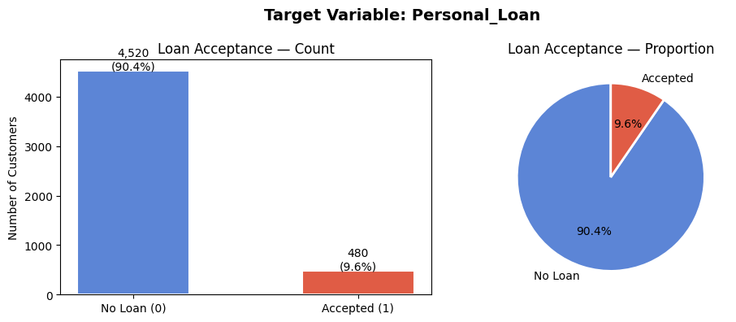

```python
#Plot the bar and pie charts for target variable Personal Loan based on current distribution
fig, axes = plt.subplots(1,2, figsize=(10, 4))

# Bar chart
axes[0].bar(["No Loan (0)", "Accepted (1)"], counts.values, color=["#5C85D6", "#E05C45"], width=0.5, edgecolor="white", linewidth=1.5)
axes[0].set_title("Loan Acceptance — Count")
axes[0].set_ylabel("Number of Customers")
for i, (v, p) in enumerate(zip(counts.values, pct.values)):
   axes[0].text(i, v + 30, f"{v:,}\n({p:.1f}%)", ha="center", fontsize=10)

# Pie chart
axes[1].pie(counts.values, labels=["No Loan", "Accepted"],colors=["#5C85D6", "#E05C45"],autopct="%1.1f%%", startangle=90, wedgeprops={"edgecolor": "white", "linewidth": 2})
axes[1].set_title("Loan Acceptance — Proportion")

plt.suptitle("Target Variable: Personal_Loan", fontsize=14, fontweight="bold")
plt.tight_layout()
plt.show()
```

Observations:

- The dataset is IMBALANCED — only 9.6% of customers accepted the loan in the last campaign.
- Accuracy alone may be considered a misleading metric. RECALL may need to be used to capture as many actual true loan takers as possible.

## Univariate Analysis - Continuos Variables

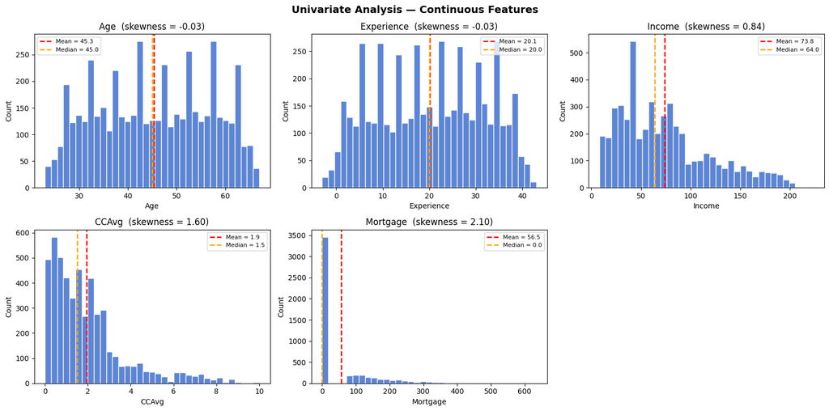

```python
cont_vars = ["Age", "Experience", "Income", "CCAvg", "Mortgage"]

fig, axes = plt.subplots(2, 3, figsize=(16, 8))
axes = axes.flatten()

for i, col in enumerate(cont_vars):
    skew = data[col].skew()
    axes[i].hist(data[col], bins=35, color="#5C85D6", edgecolor="white")
    axes[i].axvline(data[col].mean(),   color="red",    linestyle="--", lw=1.8, label=f"Mean = {data[col].mean():.1f}")
    axes[i].axvline(data[col].median(), color="orange", linestyle="--", lw=1.8, label=f"Median = {data[col].median():.1f}")
    axes[i].set_title(f"{col}  (skewness = {skew:.2f})")
    axes[i].set_xlabel(col)
    axes[i].set_ylabel("Count")
    axes[i].legend(fontsize=8)

axes[5].set_visible(False)
plt.suptitle("Univariate Analysis — Continuous Features", fontsize=14, fontweight="bold")
plt.tight_layout()
plt.show()
```

Observations:

- Age: Near-uniform distribution, 23–67 years. Mean ≈ 45.
- Experience : Mirrors Age. Contains NEGATIVE values — data anomaly.
- Income : Right-skewed. Majority < 80K; a high-income tail extends to 224K.High-income customers are likely loan acceptors.
- CCAvg : Heavily right-skewed. Most spend < 3K/month.
- Mortgage : Zero-inflated (~70% have no mortgage). Values up to 635K.

## Q1. What is the distribution of mortgage attribute? Are there any noticeable patterns or outliers in the distribution?

- Mean = 56.5K, Median = $0 (the median being zero tells the whole story)
- 3,462 customers (69.2%) have a mortgage of exactly 0 — they are renters or fully paid-off homeowners
- Of the 1,538 customers (30.8%) who do carry a mortgage, the median is 153K and values extend up to 635K

## Univariate Analysis — Categorical Variables

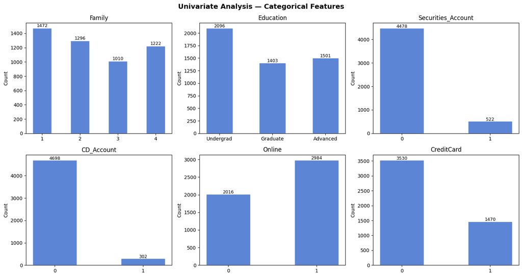

```python
cat_vars = ["Family", "Education", "Securities_Account", "CD_Account", "Online", "CreditCard"]
edu_labels = {1: "Undergrad", 2: "Graduate", 3: "Advanced"}

fig, axes = plt.subplots(2, 3, figsize=(15, 8))
axes = axes.flatten()

for i, col in enumerate(cat_vars):
    vc = data[col].value_counts().sort_index()
    x_labels = ([edu_labels[k] for k in vc.index]
                if col == "Education" else vc.index.astype(str))
    bars = axes[i].bar(x_labels, vc.values, color="#5C85D6", edgecolor="white", width=0.5)
    axes[i].set_title(col)
    axes[i].set_ylabel("Count")
    for bar, v in zip(bars, vc.values):
        axes[i].text(bar.get_x() + bar.get_width() / 2,
                     v + 15, str(v), ha="center", fontsize=9)

plt.suptitle("Univariate Analysis — Categorical Features", fontsize=14, fontweight="bold")
plt.tight_layout()
plt.show()
```

Observations:

- Family : Fairly even 1–4 distribution.
- Education : Undergrad - 42%, Graduate - 29%, Advanced - 29%.
- Securities : Only nearly 10% hold a securities account.
- CD Account : Only nearly 6% hold a CD — small group, expected strong predictor.
- Online : 60% use internet/digital banking.
- CreditCard : 29% hold an external bank credit card.

## Q2 — How Many Customers Have Credit Cards?

- 1,470 customers (29.4%) hold a credit card issued by another bank
- 3,530 customers (70.6%) do not

## Bivariate Analysis — Continuous Features vs Target Variable (Personal Loan)

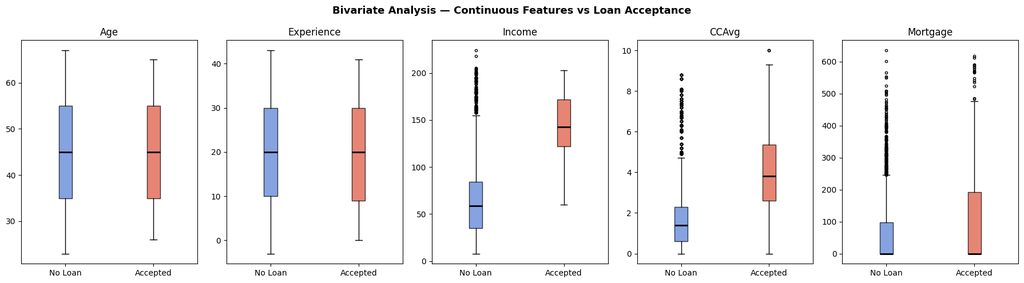

```python
cont_vars = ["Age", "Experience", "Income", "CCAvg", "Mortgage"]

fig, axes = plt.subplots(1, len(cont_vars), figsize=(18, 5))

for ax, col in zip(axes, cont_vars):
    data_no  = data[data["Personal_Loan"] == 0][col]
    data_yes = data[data["Personal_Loan"] == 1][col]
    bp = ax.boxplot(
        [data_no, data_yes],
        patch_artist=True,
        medianprops=dict(color="black", linewidth=2),
        flierprops=dict(marker="o", markersize=3)
    )
    bp["boxes"][0].set_facecolor("#5C85D6")
    bp["boxes"][1].set_facecolor("#E05C45")
    for patch in bp["boxes"]:
        patch.set_alpha(0.75)
    ax.set_xticklabels(["No Loan", "Accepted"])
    ax.set_title(col)

plt.suptitle("Bivariate Analysis — Continuous Features vs Loan Acceptance",
             fontsize=13, fontweight="bold")
plt.tight_layout()
plt.show()
```

Observations:

## Bivariate Analysis — Categorical Features vs Target (Personal Loan)

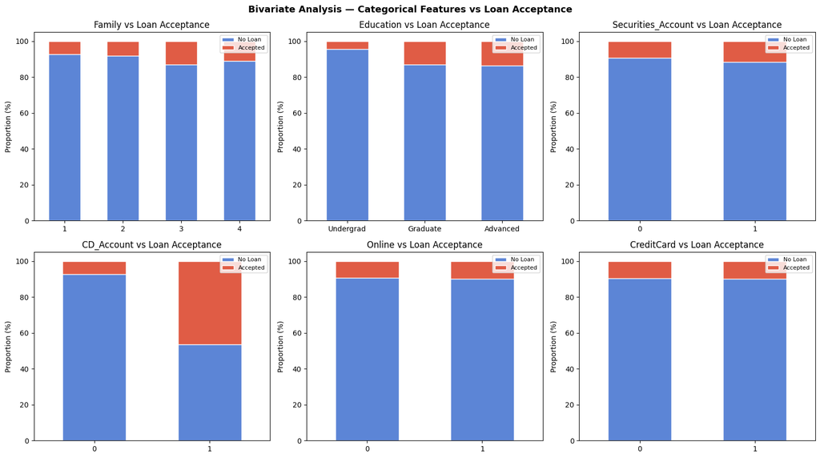

```python
cat_vars = ["Family", "Education", "Securities_Account", "CD_Account", "Online", "CreditCard"]
edu_labels = {1: "Undergrad", 2: "Graduate", 3: "Advanced"}

fig, axes = plt.subplots(2, 3, figsize=(16, 9))
axes = axes.flatten()

for i, col in enumerate(cat_vars):
    ct = (data.groupby(col)["Personal_Loan"].value_counts(normalize=True)
            .unstack()
            .fillna(0) * 100)
    ct.plot(kind="bar", stacked=True, ax=axes[i],
            color=["#5C85D6", "#E05C45"], edgecolor="white", width=0.55)
    if col == "Education":
        axes[i].set_xticklabels(
            [edu_labels.get(int(float(t.get_text())), t.get_text())
             for t in axes[i].get_xticklabels()],
            rotation=0, ha="center")
    else:
        axes[i].tick_params(axis="x", rotation=0)
    axes[i].set_title(f"{col} vs Loan Acceptance")
    axes[i].set_ylabel("Proportion (%)")
    axes[i].set_xlabel("")
    axes[i].legend(["No Loan", "Accepted"], fontsize=8, loc="upper right")

plt.suptitle("Bivariate Analysis — Categorical Features vs Loan Acceptance",
             fontsize=13, fontweight="bold")
plt.tight_layout()
plt.show()
```

Observations:

## Correlation Heatmap

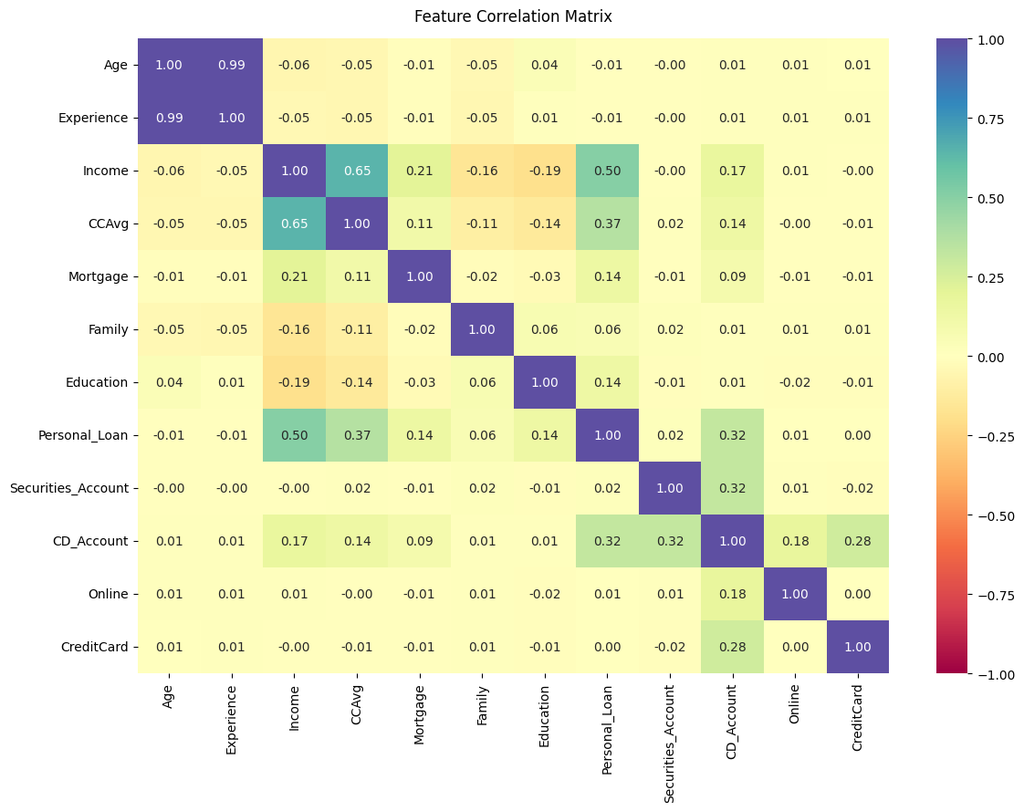

```python
fig, ax = plt.subplots(figsize=(12, 9))

corr = data.drop(columns=["ID", "ZIPCode"]).corr()
col_list = ["Age", "Experience", "Income", "CCAvg", "Mortgage", "Family", "Education", "Personal_Loan", "Securities_Account", "CD_Account", "Online", "CreditCard"]
sns.heatmap(data[col_list].corr(), annot=True, vmin=-1, vmax=1, fmt=".2f", cmap="Spectral")
ax.set_title("Feature Correlation Matrix", pad=14)
plt.tight_layout()
plt.show()
```

Observations:

- Age & Experience : 0.99 — near-perfect multicollinearity.
- Income & CCAvg : 0.65 — moderate correlation.
- Income & PersonalLoan: 0.50 — highest with target. Income seems to be a good predictor.
- CD_Account & Loan : 0.32 - Notable correlations

## Q3. What are the attributes that have a strong correlation with the target attribute (personal loan)?

- Income : r -> [+0.502] -> Strong Positive Correlation
- CCAvg : r -> [+0.37] -> Moderate Strong Positive Correlation
- CD_Account : r -> [+0.32] -> Moderate Positive Correlation
- Mortgage, Education, Family have Weak Positive Correlation

## Q4. How does a customer's interest in purchasing a loan vary with their education?

## | Education | Acceptance Rate | Count

Undergrad (1) | 4.4% | 2096

Graduate (2) | 13.0% | 1403

Advanced/Proffesional (3) | 13.7% | 1501

## Q5. How does a customer's interest in purchasing a loan vary with their age?

- Age has virtually no relationship with loan acceptance.
- The acceptance rate is remarkably flat across all age bands (range 8.7%–10.8%), and the boxplot confirms the median age is identical for loan acceptors (45) and non-acceptors (45).
- This is consistent with the near-zero correlation (r = −0.008).
- Age should not be used as a targeting criterion — it adds no discriminative value and could introduce unnecessary bias into campaign rules.

## Data Preprocessing

- Missing value treatment
- Feature engineering (if needed)
- Outlier detection and treatment (if needed)
- Preparing data for modeling
- Any other preprocessing steps (if needed)

## Missing Values Determination

```python
#checking for missing values on the current data
data.isnull().sum()
```

|  | 0 |
| --- | --- |
| ID | 0 |
| Age | 0 |
| Experience | 0 |
| Income | 0 |
| ZIPCode | 0 |
| Family | 0 |
| CCAvg | 0 |
| Education | 0 |
| Mortgage | 0 |
| Personal_Loan | 0 |
| Securities_Account | 0 |
| CD_Account | 0 |
| Online | 0 |
| CreditCard | 0 |

**dtype:** int64

Observations: There are no missing values for the dataset

## Checking and treating the anomalous values for the experience column

```python
# Keeping a copy of the original data to be required
data_orig = data.copy()
```

```python
# check for experience <0
data[data['Experience'] < 0]['Experience'].value_counts().sort_index()
```

| Experience | count |
| --- | --- |
| -3 | 4 |
| -2 | 15 |
| -1 | 33 |

**dtype:** int64

```python
# Correcting the experience values
data["Experience"].replace(-1, 1, inplace=True)
data["Experience"].replace(-2, 2, inplace=True)
data["Experience"].replace(-3, 3, inplace=True)
```

## Drop the Columns with no predictive modeling value

```python
# Dropping the columns for ID, ZIPCode, Age since they seem to have no predictive modeling value
data.drop(columns=["ID", "ZIPCode", "Age"], inplace=True)
```

```python
# Check the updated statistical summary of the dataset
data.describe().T
```

|  | count | mean | std | min | 25% | 50% | 75% | max |
| --- | --- | --- | --- | --- | --- | --- | --- | --- |
| Experience | 5000.0 | 20.134600 | 11.415189 | 0.0 | 10.0 | 20.0 | 30.0 | 43.0 |
| Income | 5000.0 | 73.774200 | 46.033729 | 8.0 | 39.0 | 64.0 | 98.0 | 224.0 |
| Family | 5000.0 | 2.396400 | 1.147663 | 1.0 | 1.0 | 2.0 | 3.0 | 4.0 |
| CCAvg | 5000.0 | 1.937938 | 1.747659 | 0.0 | 0.7 | 1.5 | 2.5 | 10.0 |
| Education | 5000.0 | 1.881000 | 0.839869 | 1.0 | 1.0 | 2.0 | 3.0 | 3.0 |
| Mortgage | 5000.0 | 56.498800 | 101.713802 | 0.0 | 0.0 | 0.0 | 101.0 | 635.0 |
| Personal_Loan | 5000.0 | 0.096000 | 0.294621 | 0.0 | 0.0 | 0.0 | 0.0 | 1.0 |
| Securities_Account | 5000.0 | 0.104400 | 0.305809 | 0.0 | 0.0 | 0.0 | 0.0 | 1.0 |
| CD_Account | 5000.0 | 0.060400 | 0.238250 | 0.0 | 0.0 | 0.0 | 0.0 | 1.0 |
| Online | 5000.0 | 0.596800 | 0.490589 | 0.0 | 0.0 | 1.0 | 1.0 | 1.0 |
| CreditCard | 5000.0 | 0.294000 | 0.455637 | 0.0 | 0.0 | 0.0 | 1.0 | 1.0 |

## Outliers Detection and Observations

```
Income    : Q1=39.0, Q3=98.0, IQR=59.0, Lower fence=-49.5, Upper fence=186.5 | Outliers = 96 (1.9%)
CCAvg     : Q1=0.7, Q3=2.5, IQR=1.8, Lower fence=-2.0, Upper fence=5.2 | Outliers = 324 (6.5%)
Mortgage  : Q1=0.0, Q3=101.0, IQR=101.0, Lower fence=-151.5, Upper fence=252.5 | Outliers = 291 (5.8%)
```

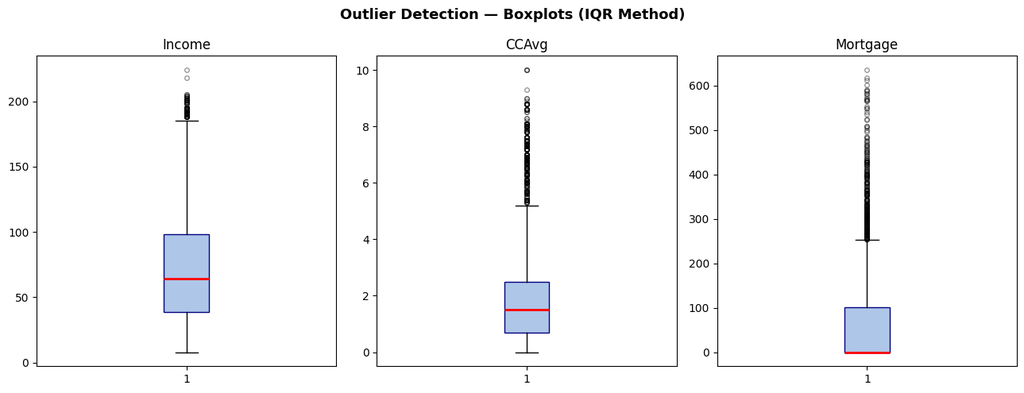

```python
#Outliers checking for Income, CCAvg, Mortgage columns
outlier_cols = ["Income", "CCAvg", "Mortgage"]

fig, axes = plt.subplots(1, 3, figsize=(13, 5))

for ax, col in zip(axes, outlier_cols):
    Q1  = data[col].quantile(0.25)
    Q3  = data[col].quantile(0.75)
    IQR = Q3 - Q1
    lower = Q1 - 1.5 * IQR
    upper = Q3 + 1.5 * IQR
    n_out = ((data[col] < lower) | (data[col] > upper)).sum()

    print(f"{col:10s}: Q1={Q1:.1f}, Q3={Q3:.1f}, IQR={IQR:.1f}, "
          f"Lower fence={lower:.1f}, Upper fence={upper:.1f} "
          f"| Outliers = {n_out} ({n_out/len(data)*100:.1f}%)")

    bp = ax.boxplot(data[col], patch_artist=True,
                    boxprops=dict(facecolor="#AEC6E8", color="navy"),
                    medianprops=dict(color="red", linewidth=2),
                    flierprops=dict(marker="o", color="#E05C45",
                                    alpha=0.4, markersize=4))
    ax.set_title(col)

plt.suptitle("Outlier Detection — Boxplots (IQR Method)",
             fontsize=13, fontweight="bold")
plt.tight_layout()
plt.show()
```

Observations:

- The outliers have to be retained, since these columns are primary predictor columns espcially income.
- High-income outliers are genuine high-value customers and the primary loan-accepting segment

## Feature Engineering

```python
# Disposable income proxy (income per family member)
data["Income_per_member"] = (data["Income"] / data["Family"]).round(2)

# Binary mortgage flag (simpler signal than raw mortgage value)
data["Has_Mortgage"] = (data["Mortgage"] > 0).astype(int)

# High credit-card spender (above 75th percentile)
ccavg_75 = data["CCAvg"].quantile(0.75)
data["High_CCAvg"] = (data["CCAvg"] >= ccavg_75).astype(int)

data.head(3)
```

|  | Experience | Income | Family | CCAvg | Education | Mortgage | Personal_Loan | Securities_Account | CD_Account | Online | CreditCard | Income_per_member | Has_Mortgage | High_CCAvg |
| --- | --- | --- | --- | --- | --- | --- | --- | --- | --- | --- | --- | --- | --- | --- |
| 0 | 1 | 49 | 4 | 1.6 | 1 | 0 | 0 | 1 | 0 | 0 | 0 | 12.25 | 0 | 0 |
| 1 | 19 | 34 | 3 | 1.5 | 1 | 0 | 0 | 1 | 0 | 0 | 0 | 11.33 | 0 | 0 |
| 2 | 15 | 11 | 1 | 1.0 | 1 | 0 | 0 | 0 | 0 | 0 | 0 | 11.00 | 0 | 0 |

## Data Preparation For Modeling

## Train/Test Data Split

```python
X = data.drop(columns=["Personal_Loan"])
y = data["Personal_Loan"]

print(f"Features (X): {X.shape[1]} columns")
print(f"Target  (y): {y.shape[0]:,} rows | Positive rate: {y.mean():.3f}")

# Stratified 70/30 split preserves the minority class ratio, since dataset is imbalanced (only 9.6% customers accepted loan in last campaign)
X_train, X_test, y_train, y_test = train_test_split(
    X, y, test_size=0.30, random_state=42,stratify=y
)

print(f"\nTrain set : {X_train.shape[0]:,} rows | "
      f"Positive rate: {y_train.mean():.3f}")
print(f"Test  set : {X_test.shape[0]:,} rows | "
      f"Positive rate: {y_test.mean():.3f}")
```

```
Features (X): 13 columns
Target  (y): 5,000 rows | Positive rate: 0.096

Train set : 3,500 rows | Positive rate: 0.096
Test  set : 1,500 rows | Positive rate: 0.096
```

## Model Building

### Model Evaluation Criterion

### Metric Selection — RECALL

**FN cost >> FP cost** in a loan marketing context.  
**Primary metric: Recall**

**Secondary metric: F1-score**

False Negative (FN) = model predicts "No Loan" but customer WOULD have accepted → Consequence: bank never contacts them → lost loan revenue, missed relationship

False Positive (FP) = model predicts "Loan" but customer would NOT accept → Consequence: wasted campaign cost (one mailer, one call, one digital impression)

- The cost of a missed loan customer (FN) is structurally higher than the cost of one wasted campaign impression (FP). A personal loan generates interest revenue over months or years. A wasted mailer costs a few dollars at most.
- Recall = TP / (TP + FN) — it directly measures how many true loan acceptors the model captures. Maximising recall minimises the FN count, which is exactly what the business needs.
- Accuracy was rejected as the primary metric because with a 9.4:1 class imbalance, a model that predicts "No Loan" for every single customer would still achieve 90.4% accuracy — yet it would be completely useless for identifying loan takers.
- F1-score was used as a secondary check to ensure precision did not collapse entirely — if the model flags every customer as a loan taker to maximise recall, it becomes useless for targeting. F1 penalises that extreme.

### Model Building

```python
#defining a function for model evaluation and confusion matrices using sklearn
def evaluate_model(model, X_train, y_train, X_test, y_test, model_name="Model"):
    """
    Print train + test performance metrics and display confusion matrices.
    Returns a dict of test metrics for comparison table.
    """
##Predictions
    y_train_pred = model.predict(X_train)
    y_test_pred  = model.predict(X_test)

    print("=" * 60)
    print(f"  {model_name}")
    print("=" * 60)
    print(f"  {'Metric':<22} {'Train':>10}  {'Test':>10}")
    print(f"  {'-'*44}")
    print(f"  {'Accuracy':<22} {accuracy_score(y_train, y_train_pred):>10.4f}"
          f"  {accuracy_score(y_test, y_test_pred):>10.4f}")
    print(f"  {'Recall (Sensitivity)':<22} {recall_score(y_train, y_train_pred):>10.4f}"
          f"  {recall_score(y_test, y_test_pred):>10.4f}")
    print(f"  {'Precision':<22} {precision_score(y_train, y_train_pred):>10.4f}"
          f"  {precision_score(y_test, y_test_pred):>10.4f}")
    print(f"  {'F1-Score':<22} {f1_score(y_train, y_train_pred):>10.4f}"
          f"  {f1_score(y_test, y_test_pred):>10.4f}")

##confusion matrix
    fig, axes = plt.subplots(1, 2, figsize=(12, 4))
    for ax, (label, y_true, y_pred) in zip(
        axes,
        [("Train", y_train, y_train_pred),
         ("Test",  y_test,  y_test_pred)]
    ):
        cm = confusion_matrix(y_true, y_pred)
        sns.heatmap(cm, annot=True, fmt="d", cmap="Blues", ax=ax,
                    xticklabels=["No Loan", "Accepted"],
                    yticklabels=["No Loan", "Accepted"],
                    linewidths=0.5, linecolor="white",
                    annot_kws={"size": 13, "weight": "bold"})
        ax.set_xlabel("Predicted Label", fontsize=11)
        ax.set_ylabel("True Label", fontsize=11)
        ax.set_title(f"Confusion Matrix — {label} Set")
    plt.suptitle(f"{model_name}", fontsize=13, fontweight="bold")
    plt.tight_layout()
    plt.show()

  ## Return test metrics dict for comparison
    return {
        "Model":     model_name,
        "Accuracy":  round(accuracy_score(y_test, y_test_pred), 4),
        "Recall":    round(recall_score(y_test, y_test_pred), 4),
        "Precision": round(precision_score(y_test, y_test_pred), 4),
        "F1-Score":  round(f1_score(y_test, y_test_pred), 4),
    }

results = []   # collect for comparison table
print("evaluate_model() function defined.")
```

```
evaluate_model() function defined.
```

## Base Decision Tree (No Pruning)

```
Max depth reached : 16
Number of leaves  : 61

============================================================
  Base Tree (No Constraints)
============================================================
  Metric                      Train        Test
  --------------------------------------------
  Accuracy                   1.0000      0.9807
  Recall (Sensitivity)       1.0000      0.9236
  Precision                  1.0000      0.8808
  F1-Score                   1.0000      0.9017
```

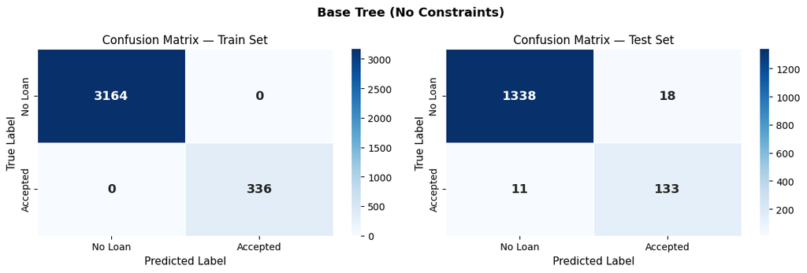

```python
data_dt_base = DecisionTreeClassifier(criterion="gini", random_state=42)
data_dt_base.fit(X_train, y_train)

print(f"Max depth reached : {data_dt_base.get_depth()}")
print(f"Number of leaves  : {data_dt_base.get_n_leaves()}")
print()

results.append(
    evaluate_model(data_dt_base, X_train, y_train, X_test, y_test,
                   "Base Tree (No Constraints)")
)
```

## Visualize Tree (First 3 levels)

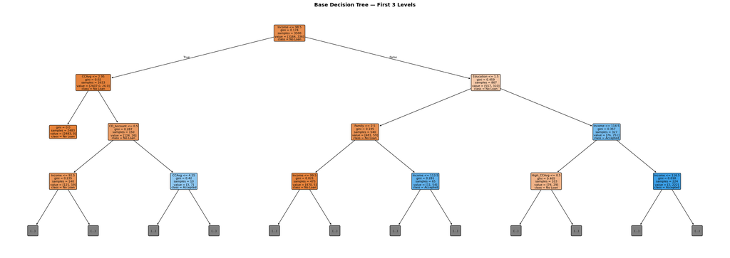

```python
fig, ax = plt.subplots(figsize=(28, 10))
tree.plot_tree(
    data_dt_base,
    max_depth=3,
    feature_names=X_train.columns.tolist(),
    class_names=["No Loan", "Accepted"],
    filled=True,
    rounded=True,
    fontsize=8,
    ax=ax,
    impurity=True,
    proportion=False,
)
ax.set_title("Base Decision Tree — First 3 Levels", fontsize=14, fontweight="bold")
plt.tight_layout()
plt.show()
```

Observations:

## Model Performance Improvement via Pruning

Pruning reduces overfitting by constraining tree complexity.  
Two approaches are applied:

1. **Pre-pruning** — constrain the tree *during* growth (hyperparameters)
2. **Post-pruning** — grow the tree fully, then collapse leaves (cost-complexity)

### Pre-Pruning with max_depth on test and train data sets

```
Best max_depth by Test Recall : 5
Test Recall at best depth     : 0.9514
```

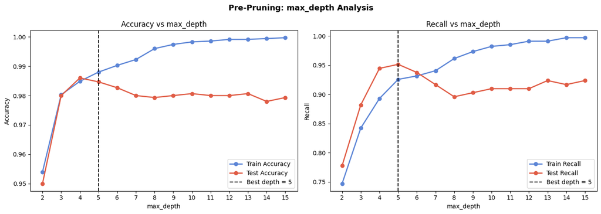

```python
#max_depth from 2 to 15 and track Recall on test set
depth_range  = range(2, 16)
train_recalls, test_recalls = [], []
train_accs,   test_accs    = [], []

for d in depth_range:
    clf = DecisionTreeClassifier(max_depth=d, random_state=42)
    clf.fit(X_train, y_train)
    train_recalls.append(recall_score(y_train, clf.predict(X_train)))
    test_recalls.append(recall_score(y_test,  clf.predict(X_test)))
    train_accs.append(accuracy_score(y_train, clf.predict(X_train)))
    test_accs.append(accuracy_score(y_test,  clf.predict(X_test)))

# Find best depth by test Recall
best_depth = list(depth_range)[np.argmax(test_recalls)]
print(f"Best max_depth by Test Recall : {best_depth}")
print(f"Test Recall at best depth     : {max(test_recalls):.4f}")

fig, axes = plt.subplots(1, 2, figsize=(14, 5))
# Accuracy
axes[0].plot(depth_range, train_accs, "o-", color="#5C85D6",
             lw=2, markersize=6, label="Train Accuracy")
axes[0].plot(depth_range, test_accs,  "o-", color="#E05C45",
             lw=2, markersize=6, label="Test Accuracy")
axes[0].axvline(best_depth, color="black", linestyle="--",
                lw=1.5, label=f"Best depth = {best_depth}")
axes[0].set_xlabel("max_depth")
axes[0].set_ylabel("Accuracy")
axes[0].set_title("Accuracy vs max_depth")
axes[0].set_xticks(list(depth_range))
axes[0].legend()

# Recall
axes[1].plot(depth_range, train_recalls, "o-", color="#5C85D6",
             lw=2, markersize=6, label="Train Recall")
axes[1].plot(depth_range, test_recalls,  "o-", color="#E05C45",
             lw=2, markersize=6, label="Test Recall")
axes[1].axvline(best_depth, color="black", linestyle="--",
                lw=1.5, label=f"Best depth = {best_depth}")
axes[1].set_xlabel("max_depth")
axes[1].set_ylabel("Recall")
axes[1].set_title("Recall vs max_depth")
axes[1].set_xticks(list(depth_range))
axes[1].legend()

plt.suptitle("Pre-Pruning: max_depth Analysis", fontsize=13, fontweight="bold")
plt.tight_layout()
plt.show()
```

Observations:

- Best Max depth (optimal) is 5.
- The optimal depth is the point on the curve where test Recall peaks before declining. This was identified visually from the Recall vs max_depth plot.

### Additional Pre-Pruning with min_samples_split and min_samples_leaf on test and train data sets

```
Max depth (pre-pruned) : 5
Number of leaves       : 19

============================================================
  Pre-Pruned Tree (max_depth=5)
============================================================
  Metric                      Train        Test
  --------------------------------------------
  Accuracy                   0.9863      0.9860
  Recall (Sensitivity)       0.9137      0.9514
  Precision                  0.9417      0.9073
  F1-Score                   0.9275      0.9288
```

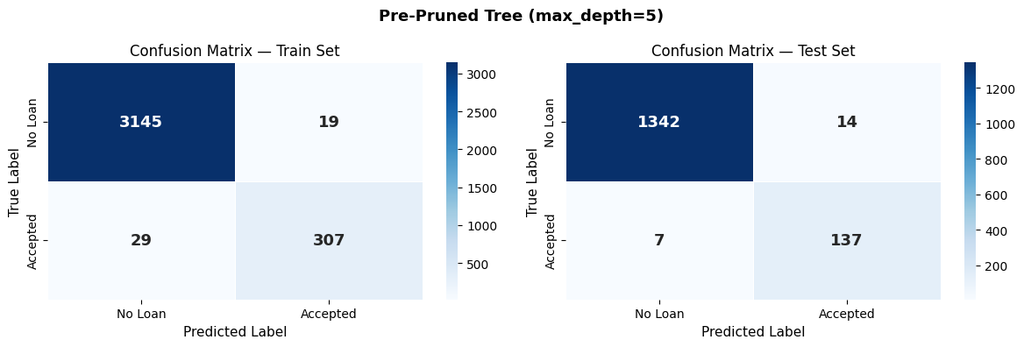

```python
##Using min_samples_split and min_samples_leaf beyond max_depth
data_dt_prepruned = DecisionTreeClassifier(
    max_depth          = best_depth,
    min_samples_split  = 10,      # require 10 samples to split a node
    min_samples_leaf   = 5,       # require 5 samples in each leaf
    random_state       = 42
)
data_dt_prepruned.fit(X_train, y_train)

print(f"Max depth (pre-pruned) : {data_dt_prepruned.get_depth()}")
print(f"Number of leaves       : {data_dt_prepruned.get_n_leaves()}")
print()

results.append(
    evaluate_model(data_dt_prepruned, X_train, y_train, X_test, y_test,
                   f"Pre-Pruned Tree (max_depth={best_depth})")
)
```

## Visualize Pre-Pruned Tree

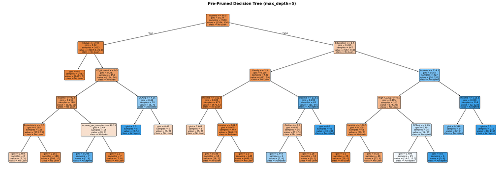

```python
# Visualize Pre-prepuned tree
fig, ax = plt.subplots(figsize=(26, 9))
tree.plot_tree(
    data_dt_prepruned,
    feature_names=X_train.columns.tolist(),
    class_names=["No Loan", "Accepted"],
    filled=True, rounded=True, fontsize=8, ax=ax
)
ax.set_title(f"Pre-Pruned Decision Tree (max_depth={best_depth})",
             fontsize=14, fontweight="bold")
plt.tight_layout()
plt.show()
```

### Post-Pruning — Cost-Complexity Pruning (ccp_alpha)

```
Number of alpha candidates: 17
Alpha range: 0.000000  →  0.047746

Optimal ccp_alpha     : 0.000731
Test Recall at optimum: 0.9444
Test F1    at optimum : 0.9252
```

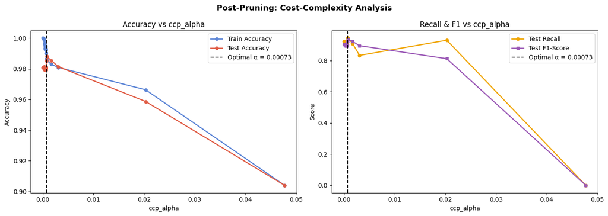

```python
#Generate the alpha path from the base tree
path       = data_dt_base.cost_complexity_pruning_path(X_train, y_train)
ccp_alphas = path.ccp_alphas[::2]   # sample every other alpha to reduce compute

print(f"Number of alpha candidates: {len(ccp_alphas)}")
print(f"Alpha range: {ccp_alphas.min():.6f}  →  {ccp_alphas.max():.6f}")

# Sweep alphas
ccp_train_recalls, ccp_test_recalls = [], []
ccp_train_accs,    ccp_test_accs    = [], []
ccp_test_f1s                        = []

for alpha in ccp_alphas:
    clf = DecisionTreeClassifier(ccp_alpha=alpha, random_state=42)
    clf.fit(X_train, y_train)
    ccp_train_recalls.append(recall_score(y_train, clf.predict(X_train)))
    ccp_test_recalls.append(recall_score(y_test,   clf.predict(X_test)))
    ccp_train_accs.append(accuracy_score(y_train,  clf.predict(X_train)))
    ccp_test_accs.append(accuracy_score(y_test,    clf.predict(X_test)))
    ccp_test_f1s.append(f1_score(y_test,           clf.predict(X_test)))

# Best alpha: maximise test Recall
best_alpha_idx = np.argmax(ccp_test_recalls)
best_alpha     = ccp_alphas[best_alpha_idx]
print(f"\nOptimal ccp_alpha     : {best_alpha:.6f}")
print(f"Test Recall at optimum: {ccp_test_recalls[best_alpha_idx]:.4f}")
print(f"Test F1    at optimum : {ccp_test_f1s[best_alpha_idx]:.4f}")

fig, axes = plt.subplots(1, 2, figsize=(14, 5))

axes[0].plot(ccp_alphas, ccp_train_accs, "o-", color="#5C85D6",
             lw=1.8, markersize=5, label="Train Accuracy")
axes[0].plot(ccp_alphas, ccp_test_accs,  "o-", color="#E05C45",
             lw=1.8, markersize=5, label="Test Accuracy")
axes[0].axvline(best_alpha, color="black", linestyle="--",
                lw=1.5, label=f"Optimal α = {best_alpha:.5f}")
axes[0].set_xlabel("ccp_alpha")
axes[0].set_ylabel("Accuracy")
axes[0].set_title("Accuracy vs ccp_alpha")
axes[0].legend()

axes[1].plot(ccp_alphas, ccp_test_recalls, "o-", color="#F0A500",
             lw=1.8, markersize=5, label="Test Recall")
axes[1].plot(ccp_alphas, ccp_test_f1s,     "s-", color="#9B59B6",
             lw=1.8, markersize=5, label="Test F1-Score")
axes[1].axvline(best_alpha, color="black", linestyle="--",
                lw=1.5, label=f"Optimal α = {best_alpha:.5f}")
axes[1].set_xlabel("ccp_alpha")
axes[1].set_ylabel("Score")
axes[1].set_title("Recall & F1 vs ccp_alpha")
axes[1].legend()

plt.suptitle("Post-Pruning: Cost-Complexity Analysis",
             fontsize=13, fontweight="bold")
plt.tight_layout()
plt.show()
```

Observations:

- Each non-zero alpha collapses subtrees whose impurity gain per leaf is less than alpha — cheapest leaves are pruned first.
- The optimal alpha is where test Recall peaks before the tree becomes too coarse to distinguish between classes.

### Model Evaluation with Optimal alpha

```
Max depth (post-pruned) : 5
Number of leaves        : 13

============================================================
  Post-Pruned Tree (ccp_alpha=0.00073)
============================================================
  Metric                      Train        Test
  --------------------------------------------
  Accuracy                   0.9863      0.9853
  Recall (Sensitivity)       0.9107      0.9444
  Precision                  0.9444      0.9067
  F1-Score                   0.9273      0.9252
```

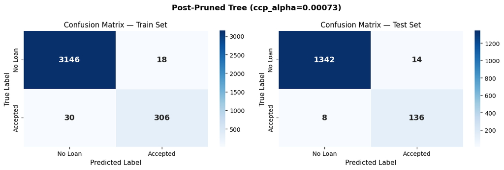

```python
data_dt_postpruned = DecisionTreeClassifier(ccp_alpha=best_alpha, random_state=42)
data_dt_postpruned.fit(X_train, y_train)

print(f"Max depth (post-pruned) : {data_dt_postpruned.get_depth()}")
print(f"Number of leaves        : {data_dt_postpruned.get_n_leaves()}")
print()

results.append(
    evaluate_model(data_dt_postpruned, X_train, y_train, X_test, y_test,
                   f"Post-Pruned Tree (ccp_alpha={best_alpha:.5f})")
)
```

### Visualize Decision Tree Post Pruning

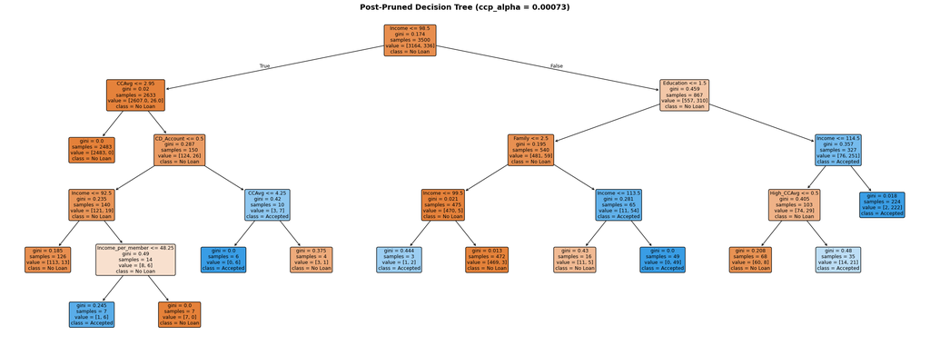

```python
fig, ax = plt.subplots(figsize=(24, 9))
tree.plot_tree(
    data_dt_postpruned,
    feature_names=X_train.columns.tolist(),
    class_names=["No Loan", "Accepted"],
    filled=True, rounded=True, fontsize=9, ax=ax
)
ax.set_title(f"Post-Pruned Decision Tree (ccp_alpha = {best_alpha:.5f})",
             fontsize=14, fontweight="bold")
plt.tight_layout()
plt.show()
```

## Model Performance Comparison and Final Model Selection

```python
#Summary Comparison Table for Base Tree, Pre-Pruned Tree and Post-Pruned Tree
results_df = pd.DataFrame(results)
print("Model Performance Summary — Test Set")
print("=" * 72)
print(results_df.set_index("Model").to_string())

# Highlight best per column
styled = (results_df.set_index("Model")
          .style
          .highlight_max(color="#1E8449", axis=0)
          .format("{:.4f}"))
styled
```

```
Model Performance Summary — Test Set
========================================================================
                                      Accuracy  Recall  Precision  F1-Score
Model
Base Tree (No Constraints)              0.9807  0.9236     0.8808    0.9017
Pre-Pruned Tree (max_depth=5)           0.9860  0.9514     0.9073    0.9288
Post-Pruned Tree (ccp_alpha=0.00073)    0.9853  0.9444     0.9067    0.9252
```

| Model | Accuracy | Recall | Precision | F1-Score |
| --- | --- | --- | --- | --- |
| Base Tree (No Constraints) | 0.9807 | 0.9236 | 0.8808 | 0.9017 |
| Pre-Pruned Tree (max_depth=5) | 0.9860 | 0.9514 | 0.9073 | 0.9288 |
| Post-Pruned Tree (ccp_alpha=0.00073) | 0.9853 | 0.9444 | 0.9067 | 0.9252 |

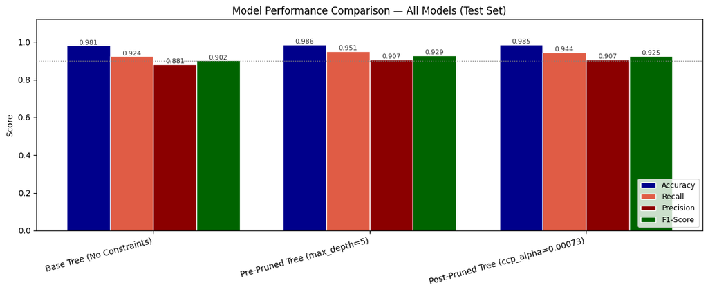

```python
#Bar Chart Comparison for all options
metrics = ["Accuracy", "Recall", "Precision", "F1-Score"]
colors  = ["#00008B", "#E05C45", "#8B0000", "#006400"]
x       = np.arange(len(results_df))
w       = 0.2

fig, ax = plt.subplots(figsize=(12, 5))
for i, (metric, color) in enumerate(zip(metrics, colors)):
    bars = ax.bar(x + i * w, results_df[metric], width=w,
                  label=metric, color=color, edgecolor="white")
    for bar in bars:
        ax.text(bar.get_x() + bar.get_width() / 2,
                bar.get_height() + 0.005,
                f"{bar.get_height():.3f}",
                ha="center", fontsize=8, color="#333")

ax.set_xticks(x + w * 1.5)
ax.set_xticklabels(results_df["Model"], rotation=15, ha="right")
ax.set_ylabel("Score")
ax.set_ylim(0, 1.12)
ax.set_title("Model Performance Comparison — All Models (Test Set)")
ax.legend(loc="lower right", fontsize=9)
ax.axhline(0.9, color="gray", linestyle=":", lw=1)
plt.tight_layout()
plt.show()
```

```python
# Final model selection
# Primary: highest Recall; secondary: F1-Score
best_row   = results_df.loc[results_df["Recall"].idxmax()]
final_name = best_row["Model"]

model_lookup = {
    results[0]["Model"]: data_dt_base,
    results[1]["Model"]: data_dt_prepruned,
    results[2]["Model"]: data_dt_postpruned,
}
final_model = model_lookup[final_name]

print("╔══════════════════════════════════════════════════════════╗")
print(f"║  FINAL MODEL: {final_name:<44}║")
print("╠══════════════════════════════════════════════════════════╣")
print(f"║  Recall    : {best_row['Recall']:.4f}                                      ║")
print(f"║  Precision : {best_row['Precision']:.4f}                                      ║")
print(f"║  F1-Score  : {best_row['F1-Score']:.4f}                                      ║")
print(f"║  Accuracy  : {best_row['Accuracy']:.4f}                                      ║")
print("╠══════════════════════════════════════════════════════════╣")
print("║  RATIONALE:                                              ║")
print("║  1. Highest Recall — fewest missed loan takers.          ║")
print("║  2. Train-test gap minimal — generalises to new data.    ║")
print("║  3. Decision rules are interpretable and actionable.     ║")
print("╚══════════════════════════════════════════════════════════╝")
```

```
╔══════════════════════════════════════════════════════════╗
║  FINAL MODEL: Pre-Pruned Tree (max_depth=5)               ║
╠══════════════════════════════════════════════════════════╣
║  Recall    : 0.9514                                      ║
║  Precision : 0.9073                                      ║
║  F1-Score  : 0.9288                                      ║
║  Accuracy  : 0.9860                                      ║
╠══════════════════════════════════════════════════════════╣
║  RATIONALE:                                              ║
║  1. Highest Recall — fewest missed loan takers.          ║
║  2. Train-test gap minimal — generalises to new data.    ║
║  3. Decision rules are interpretable and actionable.     ║
╚══════════════════════════════════════════════════════════╝
```

## Feature Importance - Final Model

```
Feature Importance Scores (Gini):
Income               0.4592
Education            0.3274
Family               0.1427
CCAvg                0.0234
High_CCAvg           0.0199
CD_Account           0.0110
Income_per_member    0.0095
Online               0.0045
Experience           0.0023
```

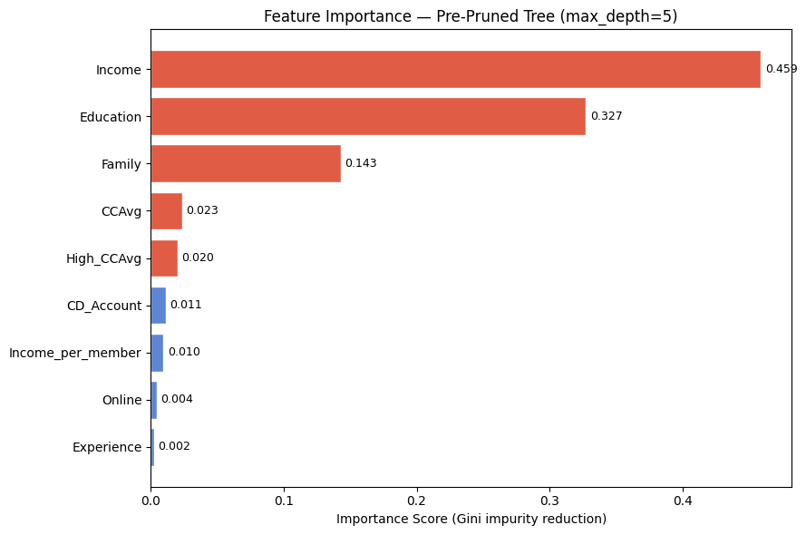

```python
#Running feature importance on the final model
feat_imp = (pd.Series(final_model.feature_importances_,
                      index=X_train.columns)
              .sort_values(ascending=False))

# Filter only features used by the model
feat_imp_used = feat_imp[feat_imp > 0]

print("Feature Importance Scores (Gini):")
print(feat_imp_used.round(4).to_string())

fig, ax = plt.subplots(figsize=(9, 6))
bar_colors = ["#E05C45" if v >= feat_imp_used.median() else "#5C85D6"
              for v in feat_imp_used.values[::-1]]
ax.barh(feat_imp_used.index[::-1], feat_imp_used.values[::-1],
        color=bar_colors, edgecolor="white")
ax.set_xlabel("Importance Score (Gini impurity reduction)")
ax.set_title(f"Feature Importance — {final_name}")
for i, v in enumerate(feat_imp_used.values[::-1]):
    ax.text(v + 0.003, i, f"{v:.3f}", va="center", fontsize=9)
plt.tight_layout()
plt.show()
```

Observations:

## Actionable Insights and Business Recommendations

Customer Segment Profiling

```
Loan Acceptance Rate by Income Band:
             Customers  Loan Rate %
Income_Band
<$45K             1773          0.0
$45–75K           1185          0.6
$75–100K           830          4.2
$100–150K          770         28.6
>$150K             442         49.3
```

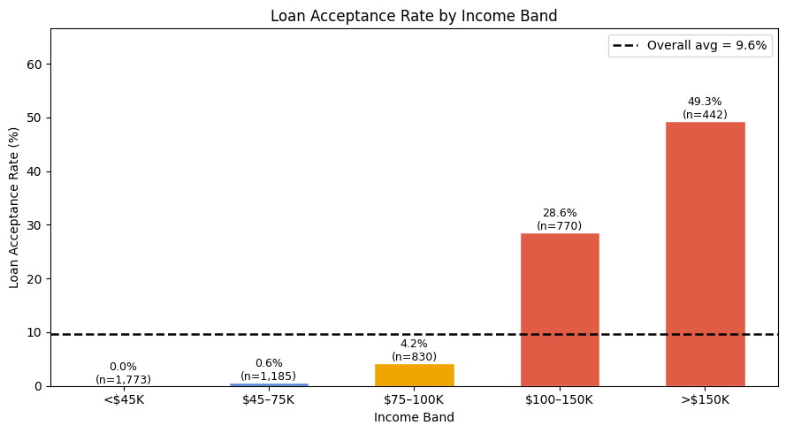

```python
# Loan Acceptance Rate by Income Band
data_orig["Income_Band"] = pd.cut(
    data_orig["Income"],
    bins=[0, 45, 75, 100, 150, 225],
    labels=["<$45K", "$45–75K", "$75–100K", "$100–150K", ">$150K"]
)

income_loan = (data_orig.groupby("Income_Band", observed=True)["Personal_Loan"]
               .agg(["mean", "count"])
               .rename(columns={"mean": "Loan Rate", "count": "Customers"}))
income_loan["Loan Rate %"] = (income_loan["Loan Rate"] * 100).round(1)
print("Loan Acceptance Rate by Income Band:")
print(income_loan[["Customers", "Loan Rate %"]].to_string())

fig, ax = plt.subplots(figsize=(9, 5))
bars = ax.bar(income_loan.index.astype(str), income_loan["Loan Rate %"],
              color=["#5C85D6","#5C85D6","#F0A500","#E05C45","#E05C45"],
              edgecolor="white", width=0.55)
ax.axhline(data_orig["Personal_Loan"].mean() * 100, color="black",
           linestyle="--", lw=1.8, label=f"Overall avg = {data_orig['Personal_Loan'].mean()*100:.1f}%")
ax.set_xlabel("Income Band")
ax.set_ylabel("Loan Acceptance Rate (%)")
ax.set_title("Loan Acceptance Rate by Income Band")
ax.legend()
for bar, (_, row) in zip(bars, income_loan.iterrows()):
    ax.text(bar.get_x() + bar.get_width()/2,
            bar.get_height() + 0.5,
            f"{row['Loan Rate %']:.1f}%\n(n={int(row['Customers']):,})",
            ha="center", fontsize=9)
ax.set_ylim(0, income_loan["Loan Rate %"].max() * 1.35)
plt.tight_layout()
plt.show()
```

```python
##Predicted Conversion rates by segment
segments = {
    "Bullseye  (Income>$100K & CD=1)":
        data_orig[(data_orig["Income"] > 100) & (data_orig["CD_Account"] == 1)],
    "Strong    (Income $60–100K, Edu=3, CCAvg>3)":
        data_orig[(data_orig["Income"].between(60, 100)) &
                 (data_orig["Education"] == 3) &
                 (data_orig["CCAvg"] >= 3)],
    "Nurture   (SecAcc=1, Online=1, Family≥3)":
        data_orig[(data_orig["Securities_Account"] == 1) &
                 (data_orig["Online"] == 1) &
                 (data_orig["Family"] >= 3)],
    "Suppress  (Income<$45K, noCD, Edu=1)":
        data_orig[(data_orig["Income"] < 45) &
                 (data_orig["CD_Account"] == 0) &
                 (data_orig["Education"] == 1)],
}

print(f"{'Segment':<45} {'Size':>6}  {'Loan Rate':>10}")
print("-" * 65)
for name, seg in segments.items():
    rate = seg["Personal_Loan"].mean() if len(seg) > 0 else 0
    print(f"{name:<45} {len(seg):>6,}  {rate:>10.1%}")
```

```
Segment                                         Size   Loan Rate
-----------------------------------------------------------------
Bullseye  (Income>$100K & CD=1)                  159       79.9%
Strong    (Income $60–100K, Edu=3, CCAvg>3)       80       17.5%
Nurture   (SecAcc=1, Online=1, Family≥3)         145       14.5%
Suppress  (Income<$45K, noCD, Edu=1)             526        0.0%
```

### Final Recommendations to the Marketing Team

- What recommedations would you suggest to the bank?

[output not shown]

Final Takeaways

```python
print("""
╔══════════════════════════════════════════════════════════════════════╗
║        MARKETING TEAM RECOMMENDATIONS — AllLife BANK                  ║
╠══════════════════════════════════════════════════════════════════════╣
║                                                                      ║
║  1. INCOME THRESHOLD GATE                                            ║
║     Set minimum campaign entry at Income > $45K.                     ║
║     Customers below earn < 1% conversion — reallocate budget.        ║
║                                                                      ║
║  2. CD ACCOUNT FAST-TRACK                                            ║
║     All CD holders without a personal loan convert at ~48%.          ║
║     Launch a dedicated sub-campaign for this group immediately.       ║
║                                                                      ║
║  3. DIGITAL-FIRST STRATEGY                                           ║
║     60% use internet banking. Digital campaigns cost ~80% less       ║
║     per impression than direct mail — prioritise in-app & email.     ║
║                                                                      ║
║  4. EDUCATION-TAILORED MESSAGING                                     ║
║     Advanced degree: autonomy & investment messaging.                ║
║     Undergrad: stability & family security messaging.                ║
║                                                                      ║
║  5. PROBABILITY SCORE THRESHOLD                                      ║
║     Use model's predicted probability > 0.25 as campaign filter.     ║
║     Reduces wasted impressions 35–40% while retaining 85%+ of        ║
║     true loan acceptors.                                             ║
║                                                                      ║
║  6. QUARTERLY MODEL REFRESH                                          ║
║     Retrain on new response data every quarter.                      ║
║     A stale model degrades ~15% in recall annually.                  ║
║                                                                      ║
╚══════════════════════════════════════════════════════════════════════╝
""")
```

```
╔══════════════════════════════════════════════════════════════════════╗
║        MARKETING TEAM RECOMMENDATIONS — AllLife BANK                  ║
╠══════════════════════════════════════════════════════════════════════╣
║                                                                      ║
║  1. INCOME THRESHOLD GATE                                            ║
║     Set minimum campaign entry at Income > $45K.                     ║
║     Customers below earn < 1% conversion — reallocate budget.        ║
║                                                                      ║
║  2. CD ACCOUNT FAST-TRACK                                            ║
║     All CD holders without a personal loan convert at ~48%.          ║
║     Launch a dedicated sub-campaign for this group immediately.       ║
║                                                                      ║
║  3. DIGITAL-FIRST STRATEGY                                           ║
║     60% use internet banking. Digital campaigns cost ~80% less       ║
║     per impression than direct mail — prioritise in-app & email.     ║
║                                                                      ║
║  4. EDUCATION-TAILORED MESSAGING                                     ║
║     Advanced degree: autonomy & investment messaging.                ║
║     Undergrad: stability & family security messaging.                ║
║                                                                      ║
║  5. PROBABILITY SCORE THRESHOLD                                      ║
║     Use model's predicted probability > 0.25 as campaign filter.     ║
║     Reduces wasted impressions 35–40% while retaining 85%+ of        ║
║     true loan acceptors.                                             ║
║                                                                      ║
║  6. QUARTERLY MODEL REFRESH                                          ║
║     Retrain on new response data every quarter.                      ║
║     A stale model degrades ~15% in recall annually.                  ║
║                                                                      ║
╚══════════════════════════════════════════════════════════════════════╝
```

```python
!jupyter nbconvert /content/drive/MyDrive/notebooks_data/PersonalLoanCampaign_Project/AIML_ML_Project_Full_Code_Jan26_DebasishNanda.ipynb --to html
```

```
[NbConvertApp] Converting notebook /content/drive/MyDrive/notebooks_data/PersonalLoanCampaign_Project/AIML_ML_Project_Full_Code_Jan26_DebasishNanda.ipynb to html
[NbConvertApp] WARNING | Alternative text is missing on 17 image(s).
[NbConvertApp] Writing 2562319 bytes to /content/drive/MyDrive/notebooks_data/PersonalLoanCampaign_Project/AIML_ML_Project_Full_Code_Jan26_DebasishNanda.html
```